# PMDDA Workflow

Miao Yu

14 January, 2022

This document is the reproducible code for PMDDA paper with extra comparison with other workflow. To access standalone PMDDA workflow, please install `rmwf` package from [GitHub](https://github.com/yufree/rmwf) and use `rmarkdown::draft("test.Rmd", template = "PMDDA", package = "rmwf")` to create a reproducible workflow document for your own studies. Such workflow is also available through [xcmsrocker](https://hub.docker.com/r/yufree/xcmsrocker/) project.

The core of PMDDA workflow include the following steps:

- MS1 full scan peak-picking.
- GlobalStd algorithm to select precursor ions for MS2 from MS1 data.
- Collect the MS2 data and annotation with GNPS.

# MS1 data collection

The MS1 full scan data used in this study could be accessed from figshare and the details are given as comments in this chunk. Those data include five NIST1950 samples and five matrix samples from positive and negative mode, respectively. Those data are also available on GitHub.

```r
options(timeout=600)
# Download data using rfigshare package
library(rfigshare)
# create data folder for MS1 positive data
dir.create(file.path('data'), showWarnings = FALSE)
setwd(file.path('data'))

# download NIST1950 MS1 positive data into nist1950 folder
dir.create(file.path('nist1950'), showWarnings = FALSE)
setwd(file.path('nist1950'))
article_id <- 13252196
details <- fs_details(article_id, mine = FALSE, session = NULL)
name <- sapply(details$files,function(x) x$name)
url <- sapply(details$files,function(x) x$download_url)
download.file(url, name, method = 'libcurl')

# download matrix MS1 positive data into matrix folder
setwd('..')
dir.create(file.path('matrix'), showWarnings = FALSE)
setwd(file.path('matrix'))
article_id <- 13252244
details <- fs_details(article_id, mine = FALSE, session = NULL)
name <- sapply(details$files,function(x) x$name)
url <- sapply(details$files,function(x) x$download_url)
download.file(url, name, method = 'libcurl')
setwd('..')
path <- getwd()
# get the files name of positive MS1 data
files <- list.files(path,pattern = '*.mzML',recursive = T,full.names = T)
setwd('..')

# create datan folder for MS1 negative data
dir.create(file.path('datan'), showWarnings = FALSE)
setwd(file.path('datan'))

# download NIST1950 MS1 negative data into nist1950n folder
dir.create(file.path('nist1950n'), showWarnings = FALSE)
setwd(file.path('nist1950n'))
article_id <- 13252274
details <- fs_details(article_id, mine = FALSE, session = NULL)
name <- sapply(details$files,function(x) x$name)
url <- sapply(details$files,function(x) x$download_url)
download.file(url, name, method = 'libcurl')
setwd('..')

# download matrix MS1 negative data into matrixn folder
dir.create(file.path('matrixn'), showWarnings = FALSE)
setwd(file.path('matrixn'))
article_id <- 13252355
details <- fs_details(article_id, mine = FALSE, session = NULL)
name <- sapply(details$files,function(x) x$name)
url <- sapply(details$files,function(x) x$download_url)
download.file(url, name, method = 'libcurl')
setwd('..')
path <- getwd()
filesn <- list.files(path,pattern = '*.mzML',recursive = T,full.names = T)
setwd('..')
```

# Optimization of XCMS

This chunk should run first to generate XCMS parameters. We suggest a computer with large memory to run this chunk for IPO package.

## IPO

This chunk will generate ‘para.RData’(positive) and ‘paran.RData’ (negative) to save the optimized parameters for xcms peak picking. For the usage of IPO package, check [here](https://www.bioconductor.org/packages/release/bioc/html/IPO.html) for technique details.

```r
path <- 'data/nist1950'
files <- list.files(path,pattern = '*.mzML',recursive = T,full.names = T)
library(IPO)
library(xcms)
peakpickingParameters <- getDefaultXcmsSetStartingParams('centWave')
# Uncomment this line to use your own data(suggested 3-5 pooled QC samples)
# path <- 'path/to/your/files'
# change to 5 for obitrap
peakpickingParameters$ppm <- 10
resultPeakpicking <-
  optimizeXcmsSet(files = files[c(1,3,5)],
                  params = peakpickingParameters,
                  plot = F,
                  subdir = NULL)

optimizedXcmsSetObject <- resultPeakpicking$best_settings$xset
retcorGroupParameters <- getDefaultRetGroupStartingParams()
retcorGroupParameters$minfrac <- 1
resultRetcorGroup <-
  optimizeRetGroup(xset = optimizedXcmsSetObject,
                   params = retcorGroupParameters,
                   plot = F,
                   subdir = NULL)
para <- c(resultPeakpicking$best_settings$parameters,
          resultRetcorGroup$best_settings)
save(para,file = 'para.RData')

path <- 'datan/nist1950n'
files <- list.files(path,pattern = '*.mzML',recursive = T,full.names = T)
library(IPO)
library(xcms)
peakpickingParameters <- getDefaultXcmsSetStartingParams('centWave')
# Uncomment this line to use your own data(suggested 3-5 pooled QC samples)
# path <- 'path/to/your/files'
# change to 5 for obitrap
peakpickingParameters$ppm <- 10
resultPeakpicking <-
  optimizeXcmsSet(files = files[c(1,3,5)],
                  params = peakpickingParameters,
                  plot = F,
                  subdir = NULL)

optimizedXcmsSetObject <- resultPeakpicking$best_settings$xset
retcorGroupParameters <- getDefaultRetGroupStartingParams()
retcorGroupParameters$minfrac <- 1
resultRetcorGroup <-
  optimizeRetGroup(xset = optimizedXcmsSetObject,
                   params = retcorGroupParameters,
                   plot = F,
                   subdir = NULL)
para <- c(resultPeakpicking$best_settings$parameters,
          resultRetcorGroup$best_settings)
save(para,file = 'paran.RData')
```

## Wrap function for peak picking

This chunk could be run after you have optimized IPO parameters from last chunk to load the parameters as function. Here we use xcms 3 for peak picking and check [here](https://www.bioconductor.org/packages/release/bioc/html/xcms.html) for the technique details of their parameters.

```r
library(xcms)
# here we use pre-optimized IPO parameters
# Or you could load your own set from last chunk
# Positive mode
para <- readRDS('para.RDS')
getrtmz <- function(path,index = NULL){
  files <- list.files(path,pattern = ".CDF|.mzXML|.mzML",full.names = T,recursive = T)
  if(!is.null(index)){
    files<- files[index]
    }
  group <- xcms:::phenoDataFromPaths(files)
  if(NCOL(group)==1){
      sample_group <- group$class
  }else{
      cols <- colnames(group)
      sample_group <-  do.call(paste,c(group[cols],sep='_'))
  }
  sample_name=sub(basename(files),pattern = ".CDF|.mzXML|.mzML",replacement = '')
  pd <- cbind.data.frame(sample_name, sample_group)

  raw_data <- readMSData(files = files, pdata = new("NAnnotatedDataFrame", pd),
                       mode = "onDisk")
  # remove co-elution and column wash phase
  # filter_data <- filterRt(raw_data,rt = c(100,900))
  cwp <- CentWaveParam(peakwidth = c(para$min_peakwidth,para$max_peakwidth),
                       ppm             = para$ppm,
                       noise           = para$noise,
                       snthresh        = para$snthresh,
                       mzdiff          = para$mzdiff,
                       prefilter       = c(para$prefilter,para$value_of_prefilter),
                       mzCenterFun     = para$mzCenterFun,
                       integrate       = para$integrate,
                       fitgauss        = para$fitgauss,
                       verboseColumns  = para$verbose.columns)
  owp <- ObiwarpParam(binSize        = para$profStep,
                      centerSample   = 6,
                      response       = para$response,
                      distFun        = para$distFunc,
                      gapInit        = para$gapInit,
                      gapExtend      = para$gapExtend,
                      factorDiag     = para$factorDiag,
                      factorGap      = para$factorGap,
                      localAlignment = ifelse(para$localAlignment==0,F,T))
  pdp <- PeakDensityParam(sampleGroups = pd$sample_group,
                        bw      = para$bw,
                        minFraction = para$minfrac,
                        minSamples = para$minsamp,
                        maxFeatures = para$max,
                        binSize = para$mzwid)
  MSnbase::setMSnbaseFastLoad(FALSE)
  xdata <- findChromPeaks(raw_data, param = cwp)
  # xdata <- findChromPeaks(filter_data, param = cwp)
  xdata <- adjustRtime(xdata, param = owp)
  xdata <- groupChromPeaks(xdata, param = pdp)
  xdata <- fillChromPeaks(xdata)
  return(xdata)
}
# Negative mode
paran <- readRDS('paran.RDS')
getrtmzn <- function(path,index = NULL){
  files <- list.files(path,pattern = ".CDF|.mzXML|.mzML",full.names = T,recursive = T)
  if(!is.null(index)){
    files<- files[index]
    }
  group <- xcms:::phenoDataFromPaths(files)
  if(NCOL(group)==1){
      sample_group <- group$class
  }else{
      cols <- colnames(group)
      sample_group <-  do.call(paste,c(group[cols],sep='_'))
  }
  sample_name=sub(basename(files),pattern = ".CDF|.mzXML|.mzML",replacement = '')
  pd <- cbind.data.frame(sample_name, sample_group)

  raw_data <- readMSData(files = files, pdata = new("NAnnotatedDataFrame", pd),
                       mode = "onDisk")
  # remove co-elution and column wash phase
  # filter_data <- filterRt(raw_data,rt = c(100,900))
  cwp <- CentWaveParam(peakwidth = c(para$min_peakwidth,para$max_peakwidth),
                       ppm             = paran$ppm,
                       noise           = paran$noise,
                       snthresh        = paran$snthresh,
                       mzdiff          = paran$mzdiff,
                       prefilter       = c(para$prefilter,para$value_of_prefilter),
                       mzCenterFun     = paran$mzCenterFun,
                       integrate       = paran$integrate,
                       fitgauss        = paran$fitgauss,
                       verboseColumns  = paran$verbose.columns)
  owp <- ObiwarpParam(binSize        = paran$profStep,
                      centerSample   = 6,
                      response       = paran$response,
                      distFun        = paran$distFunc,
                      gapInit        = paran$gapInit,
                      gapExtend      = paran$gapExtend,
                      factorDiag     = paran$factorDiag,
                      factorGap      = paran$factorGap,
                      localAlignment = ifelse(paran$localAlignment==0,F,T))
  pdp <- PeakDensityParam(sampleGroups = pd$sample_group,
                        bw      = paran$bw,
                        minFraction = paran$minfrac,
                        minSamples = paran$minsamp,
                        maxFeatures = paran$max,
                        binSize = paran$mzwid)
  MSnbase::setMSnbaseFastLoad(FALSE)
  xdata <- findChromPeaks(raw_data, param = cwp)
  # xdata <- findChromPeaks(filter_data, param = cwp)
  xdata <- adjustRtime(xdata, param = owp)
  xdata <- groupChromPeaks(xdata, param = pdp)
  xdata <- fillChromPeaks(xdata)
  return(xdata)
}
```

# Peaks list

This section is used to generate peaks list and related csv files for further analysis.

## Peak picking

This chunk will use the optimized xcms parameters for peak picking. This chunk will generate srmmzrt.csv, srmnmzrt.csv to save the peaks list from positive and negative mode MS1 full scan. The code will also save corresponding xcmsSet object for RAMClustR and CAMERA package.

```r
# use your own data by changing the data path
# Positive mode
path <- 'data/'
srm <- getrtmz(path,index = c(1:10))
# back up peak list as csv file and xcmsSet object
mzrt <- enviGCMS::getmzrt(srm, name = 'srm')
# Negative mode
path <- 'datan/'
srmn <- getrtmzn(path,index = c(1:10))
# back up peak list as csv file and xcmsSet object
mzrtn <- enviGCMS::getmzrt(srmn, name = 'srmn')
```

## Peak filtering

This chunk will use peak list csv file as input to perform peak filtering based on matrix sample and RSD% cutoff.

This chunk will save the filtered peaks list as `rppmzrt.csv` and `rpnmzrt.csv` for positive and negative mode.

```r
# Positive data
mzrt <- enviGCMS::getmzrtcsv('srmmzrt.csv')
# calculate group mean and rsd%
mzrtm <- enviGCMS::getdoe(mzrt)
gm <- mzrtm$groupmean
gr <- mzrtm$grouprsd
# find the blank group and pool QC group, demo data only have matrix blank
srm <- grepl('nist',colnames(gm))
blk <- grepl('matrix',colnames(gm))
# pqc <- grepl('pool',colnames(gm))
# filter by pool QC and blank's group mean intensity(pool QC should larger than three times of blank), return numbers and index
# in demo data, use sample average intensity for each peak
sum(indexmean <- apply(gm,1,function(x) all(x[srm]> 3*x[blk])))
# filter by pool qc rsd%, return numbers and index
# select rsd% cutoff 30
rsdcf <- 30
sum(indexrsd <- apply(gr,1,function(x) ifelse(is.na(x[srm]),T,x[srm]<rsdcf)))
# overlap with rsd% and mean filter
sum(index <- indexmean&indexrsd)
# 4711
qcindex <- grepl('matrix',mzrt$group$sample_group)
mzrtfilter <- enviGCMS::getfilter(mzrt,rowindex = index)
# save the filtered peak list
enviGCMS::getcsv(mzrtfilter,'rpp')
# Negative data
mzrt <- enviGCMS::getmzrtcsv('srmnmzrt.csv')
# calculate group mean and rsd%
mzrtm <- enviGCMS::getdoe(mzrt)
gm <- mzrtm$groupmean
gr <- mzrtm$grouprsd
# find the blank group and pool QC group, demo data only have matrix blank
srm <- grepl('nist',colnames(gm))
blk <- grepl('matrix',colnames(gm))
# pqc <- grepl('pool',colnames(gm))
# filter by pool QC and blank's group mean intensity(pool QC should larger than three times of blank), return numbers and index
# in demo data, use sample average intensity for each peak
sum(indexmean <- apply(gm,1,function(x) all(x[srm]> 3*x[blk])))
# filter by pool qc rsd%, return numbers and index
# select rsd% cutoff 30
rsdcf <- 30
sum(indexrsd <- apply(gr,1,function(x) ifelse(is.na(x[2]),T,x[2]<rsdcf)))
# overlap with rsd% and mean filter
sum(indexn <- indexmean&indexrsd)
# 3608
# new list, update group and remove pool qc/blk and save the new csv file
qcindex <- grepl('matrix',mzrt$group$sample_group)
mzrtfiltern <- enviGCMS::getfilter(mzrt,rowindex = indexn)
sum(index <- indexmean&indexrsd)
enviGCMS::getcsv(mzrtfiltern,'rpn')
```

## Precursor selection

This section will select the precursor ions from MS1 full scan data for MS2 spectra data collection.

### CAMERA

This chunk is the code to extract precursor ions list by CAMERA package. Noticing CAMERA is not designed for this purpose. This chunk will generate `cameratar.csv` and `camerantar.csv` to save the selected precursors from CAMERA package.

```r
# load object for CAMERA
srmxset <- readRDS("srmxset.rds")
srmnxset <- readRDS("srmnxset.rds")
# CAMERA
# Positive mode
xsa <- CAMERA::annotate(srmxset, perfwhm=0.7, cor_eic_th=0.75,
ppm=10, polarity="positive")
peaklist <- CAMERA::getPeaklist(xsa)
peaklist$meanpeak <- apply(peaklist[,c(15:19)],1,mean)
length(unique(peaklist$pcgroup))
grouprt <- aggregate(peaklist$rt,by=list(peaklist$pcgroup), median)
grouprt$psgrp <- as.numeric(grouprt$Group.1)
grouprt2 <- merge(data.frame(xsa@annoGrp),grouprt,by='psgrp')
cre <- cbind.data.frame(mz=grouprt2$mass+1.0073,rt=grouprt2$x)
write.csv(cre,'cameratar.csv')
cre <- read.csv('cameratar.csv')
# 862

# Negative mode
xsa <- CAMERA::annotate(srmnxset, perfwhm=0.7, cor_eic_th=0.75,
ppm=10, polarity="negative")
peaklistn <- CAMERA::getPeaklist(xsa)
peaklistn$meanpeak <- apply(peaklistn[,c(15:19)],1,mean)
length(unique(peaklistn$pcgroup))
grouprt <- aggregate(peaklistn$rt,by=list(peaklistn$pcgroup), median)
grouprt$psgrp <- as.numeric(grouprt$Group.1)
grouprt2 <- merge(data.frame(xsa@annoGrp),grouprt,by='psgrp')
cren <- cbind.data.frame(mz=grouprt2$mass-1.0073,rt=grouprt2$x)
write.csv(cren,'camerantar.csv')
cren <- read.csv('camerantar.csv')
# 710
```

### RAMClustR

This chunk is the code to extract precursor ions list by RAMClustR package. Noticing RAMClustR is not designed for this purpose. This chunk will generate `ramclusttar.csv` and `ramclustntar.csv` to save the selected precursors from RAMClustR package.

```r
srmxset <- readRDS("srmxset.rds")
srmnxset <- readRDS("srmnxset.rds")
# Positive mode
rcp <- RAMClustR::ramclustR(srmxset)
RC <- RAMClustR::do.findmain(rcp, mode = "positive", mzabs.error = 0.02, ppm.error = 10)
meanpeak <- apply(t(rcp$MSdata),1,mean)
df <-  cbind.data.frame(mz = rcp$fmz, rt = rcp$frt, cluster = rcp$featclus,meanpeak)
mol <- data.frame(mz = RC$M+1.0073,rt=RC$clrt)
write.csv(mol,'ramclusttar.csv')
rre <- read.csv('ramclusttar.csv')
# 542

# Negative mode
rcp <- RAMClustR::ramclustR(srmnxset)
RC <- RAMClustR::do.findmain(rcp, mode = "negative", mzabs.error = 0.02, ppm.error = 10)
meanpeak <- apply(t(rcp$MSdata),1,mean)
dfn <-  cbind.data.frame(mz = rcp$fmz, rt = rcp$frt, cluster = rcp$featclus,meanpeak)
moln <- data.frame(mz = RC$M-1.0073,rt=RC$clrt)
write.csv(moln,'ramclustntar.csv')
rren <- read.csv('ramclustntar.csv')
# 770
```

### pmd

This chunk is the code to extract precursor ions list by pmd package and GlobalStd algorithm. This chunk will generate `pretar.csv` and `prentar.csv` to save the selected precursors from pmd package.

```r
# PMD
pos <- enviGCMS::getmzrtcsv('rppmzrt.csv')
neg <- enviGCMS::getmzrtcsv('rpnmzrt.csv')
# perform GlobalStd algorithm
pospmd <- pmd::globalstd(pos,sda=F,ng = NULL)
# 849
pospmd2 <- pmd::getcluster(pospmd,corcutoff = 0.9)
sum(pospmd2$stdmassindex2)
# 780
# generate the targeted ions list
pre <- cbind.data.frame(mz=pospmd2$mz[pospmd2$stdmassindex2],rt=pospmd2$rt[pospmd2$stdmassindex2])
write.csv(pre,'pretar.csv')
pre <- read.csv('pretar.csv')

negpmd <- pmd::globalstd(neg,sda=F,ng = NULL)
# 761
negpmd2 <- pmd::getcluster(negpmd,corcutoff = 0.9)
sum(negpmd2$stdmassindex2)
# 723
pren <- cbind.data.frame(mz=negpmd2$mz[negpmd2$stdmassindex2],rt=negpmd2$rt[negpmd2$stdmassindex2])
write.csv(pren,'prentar.csv')
pren <- read.csv('prentar.csv')
# 723
```

GlobalStd algorithm will not use predefined redundant peaks information and the unknown adducts can be found based on frequency in the data. This chunk will generate figure S4 and S5 for positive and negative mode data.

```r
# PMD
pos <- enviGCMS::getmzrtcsv('rppmzrt.csv')
neg <- enviGCMS::getmzrtcsv('rpnmzrt.csv')

pospmd <- pmd::globalstd(pos,sda=F,ng = NULL)
```

```
## 98 retention time cluster found.
```

```
## 1987 paired masses found
```

```
## 37 unique within RT clusters high frequency PMD(s) used for further investigation.
```

```
## The unique within RT clusters high frequency PMD(s) is(are)  21.98 36 15.97 28 26.02 48 4.98 8.99 42.01 44.03 33.98 13.98 18.01 12 39.99 28.03 2.02 15.01 2.01 24 8.03 19.99 31.94 7.99 5.99 4.96 22.99 9.01 60.06 10.99 72.96 41.03 0.5 8.49 117.08 15.98 50.96.
```

```
## 2775 isotopologue(s) related paired mass found.
```

```
## 1769 multi-charger(s) related paired mass found.
```

```
## 0 retention group(s) have single peaks.
```

```
## 1 group(s) with multiple peaks while no isotope/paired relationship 95
```

```
## 7 group(s) with multiple peaks with isotope without paired relationship 7 18 21 40 42 46 98
```

```
## 2 group(s) with paired relationship without isotope 35 97
```

```
## 88 group(s) with paired relationship and isotope 1 2 3 4 5 6 8 9 10 11 12 13 14 15 16 17 19 20 22 23 24 25 26 27 28 29 30 31 32 33 34 36 37 38 39 41 43 44 45 47 48 49 50 51 52 53 54 55 56 57 58 59 60 61 62 63 64 65 66 67 68 69 70 71 72 73 74 75 76 77 78 79 80 81 82 83 84 85 86 87 88 89 90 91 92 9…
```

```
## 849 std mass found.
```

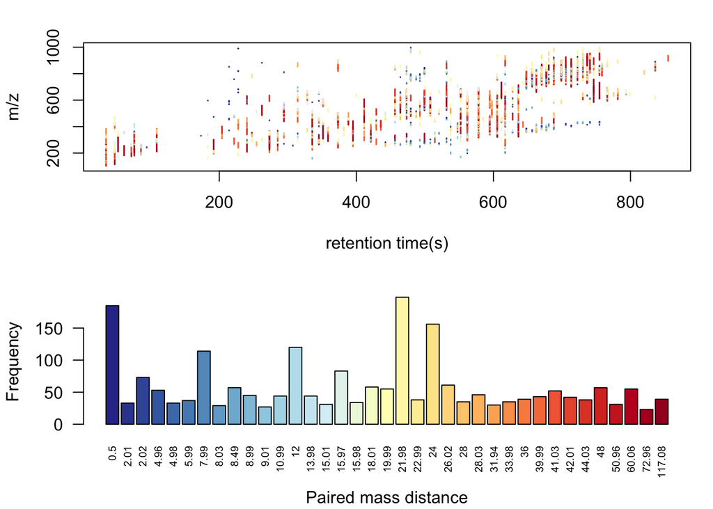

```r
# png('pospaired.png',width = 1500, height = 1500, res=300)
pmd::plotpaired(pospmd)
```

```r
# dev.off()
negpmd <- pmd::globalstd(neg,sda=F,ng = NULL)
```

```
## 86 retention time cluster found.
```

```
## 1339 paired masses found
```

```
## 39 unique within RT clusters high frequency PMD(s) used for further investigation.
```

```
## The unique within RT clusters high frequency PMD(s) is(are)  12 26.02 43.99 49.98 67.99 94.01 24 48 104.04 18.01 42.01 30.01 54.01 10.03 27.02 58.03 78.01 16.99 145.93 2.02 61.97 77.94 15.97 6.02 31.94 41.97 21.98 129.96 99.92 87.97 146 46.01 135.97 203.96 78.02 139.99 147.93 22 36.05.
```

```
## 2288 isotopologue(s) related paired mass found.
```

```
## 485 multi-charger(s) related paired mass found.
```

```
## 0 retention group(s) have single peaks.
```

```
## 2 group(s) with multiple peaks while no isotope/paired relationship 10 11
```

```
## 8 group(s) with multiple peaks with isotope without paired relationship 5 7 16 25 34 38 65 68
```

```
## 0 group(s) with paired relationship without isotope
```

```
## 76 group(s) with paired relationship and isotope 1 2 3 4 6 8 9 12 13 14 15 17 18 19 20 21 22 23 24 26 27 28 29 30 31 32 33 35 36 37 39 40 41 42 43 44 45 46 47 48 49 50 51 52 53 54 55 56 57 58 59 60 61 62 63 64 66 67 69 70 71 72 73 74 75 76 77 78 79 80 81 82 83 84 85 86
```

```
## 761 std mass found.
```

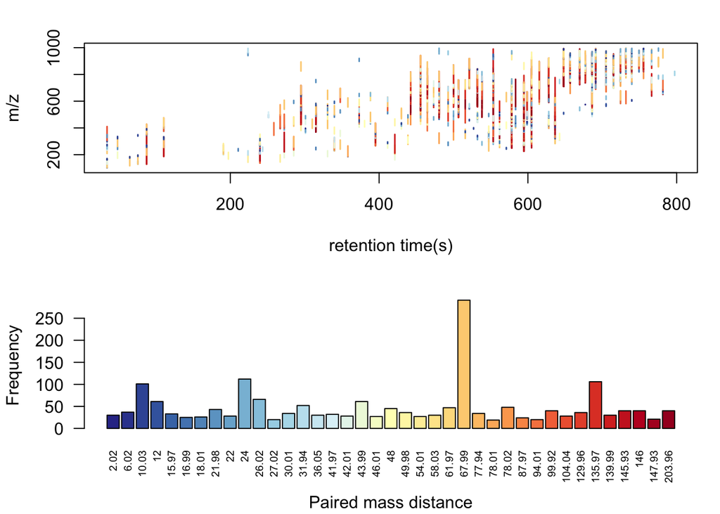

```r
# png('negpaired.png',width = 1500, height = 1500, res=300)
pmd::plotpaired(negpmd)
```

```r
# dev.off()
```

### Generate peaks list for multiple injections

Those functions are designed for multiple injections. Please read the purpose of each function in the comments and do not change the function unless you know what you are doing.

```r
# pmdtarget is used to generate precursor ions list for targeted analysis
pmdtarget <- function(list,Dppm = 20,Drt = 0.5,ce = NA, name = 'target',n=NULL){
        head <-  c('On', 'Prec. m/z', 'Z','Ret. Time (min)', 'Delta Ret. Time (min)', 'Iso. Width', 'Collision Energy')
        mz <- list$mz[list$stdmassindex]
        rt <- round(list$rt[list$stdmassindex]/60,3)
        temp = cbind('TRUE',mz,1,rt,Drt,'Narrow (~1.3 m/z)',ce)
        data <- rbind(head,temp)
        colnames(data) <- c('TargetedMSMSTable',rep('',6))

        if(is.null(n)){
                name2 <- paste0(name,'.csv')
                utils::write.table(data,file = name2,row.names = F,col.names = F,sep=",")

        }else{
                idx <- targetsep(list$rt[list$stdmassindex],Drt,n)
                for(i in 1:length(table(idx))){
                        namei <- paste0(name,i,'.csv')
                        idx2 <- idx == i
                        idx3 <- c(T,idx2)
                        datai <- data[idx3,]
                        utils::write.table(datai,file = namei,row.names = F,col.names = F,sep=",")
                }
        }

        return(data)
}
# gettarget is used to generate list for targeted analysis
gettarget <- function(mz,rt,Drt=0.5,Dppm=20,ce=NA,name,n=NULL){
  head <-  c('On', 'Prec. m/z', 'Z','Ret. Time (min)', 'Delta Ret. Time (min)', 'Iso. Width', 'Collision Energy')
        rtn <- round(rt/60,3)
        temp = cbind('TRUE',mz,1,rtn,Drt,'Narrow (~1.3 m/z)',ce)
        data <- rbind(head,temp)
        colnames(data) <- c('TargetedMSMSTable',rep('',6))

        if(is.null(n)){
                name2 <- paste0(name,'.csv')
                utils::write.table(data,file = name2,row.names = F,col.names = F,sep=",")

        }else{
                idx <- targetsep(rt,Drt,n)
                for(i in 1:length(table(idx))){
                        namei <- paste0(name,i,'.csv')
                        idx2 <- idx == i
                        idx3 <- c(T,idx2)
                        datai <- data[idx3,]
                        utils::write.table(datai,file = namei,row.names = F,col.names = F,sep=",")
                }
        }

        return(data)
}
# targetsep is used to split peaks list base on retention time, retention time range and the max scans per second (n).
targetsep <- function(rt,Drt,n=6,seed=42){
        set.seed(seed)
        D <- Drt*60
        dis <- stats::dist(rt, method = "manhattan")
        fit <- stats::hclust(dis)
        inji <- rtcluster <- stats::cutree(fit, h = D)
        maxd <- max(table(rtcluster))
        m <- length(unique(rtcluster))
        inj <- ceiling(maxd/n)
        message(paste('You need',inj,'injections!'))
        for(i in c(1:m)) {
                z = 1:inj
                x <- rt[rtcluster==i]
                while(length(x) > inj & length(x)>n){
                        t <- sample(x,n)
                        w <- sample(z,1)
                        inji[rt %in% t] <- w
                        z <- z[!(z%in%w)]
                        x <- x[!(x %in% t)]
                }
                inji[rtcluster==i & rt %in% x] <- sample(z,sum(rtcluster==i & rt %in% x),replace = T)
        }
        return(inji)
}
```

This chunk will use the predefined function in the beginning to generate precursor ions list for targeted multiple injections to collect MS2 data. Then manually move the files to `postar` and `negtar` folders to collect MS2 data from instruments.

```r
# generate precursor peaks list for MS2 targeted analysis
rt <- gettarget(rre$mz,rre$rt,n=6,Drt = 0.2,ce=20,name = 'ramclustr')
ct <- gettarget(cre$mz,cre$rt,n=6,Drt = 0.2,ce=20,name = 'CAMERA')
pt <- gettarget(pre$mz,pre$rt,n=6,Drt = 0.2,ce=20,name = 'pmd')
rtn <- gettarget(rren$mz,rren$rt,n=6,Drt = 0.2,ce=20,name = 'ramclustrn')
ctn <- gettarget(cren$mz,cren$rt,n=6,Drt = 0.2,ce=20,name = 'CAMERAn')
ptn <- gettarget(pren$mz,pren$rt,n=6,Drt = 0.2,ce=20,name = 'pmdn')
```

## NIST Known compounds

This section will compare the known compounds in NIST1950 among different annotation workflow. Those known compounds are in `nist1950.csv`.

```r
# import NIST known compounds
target <- read.csv('nist1950.csv',stringsAsFactors = F)
# generate protonated and deprotonated ions for positive and negative mode
masspos <- target$massall[!is.na(target$massall)]+1.0079
massneg <- target$massall[!is.na(target$massall)]-1.0079

pre <- read.csv('pretar.csv')
pren <- read.csv('prentar.csv')
rre <- read.csv('ramclusttar.csv')
rren <- read.csv('ramclustntar.csv')
cre <- read.csv('cameratar.csv')
cren <- read.csv('camerantar.csv')
# Check the coverage of known compounds
sum(unique(round(rre$mz,2)) %in% round(masspos,2))
```

```
## [1] 5
```

```r
# 5
sum(unique(round(pre$mz,2)) %in% round(masspos,2))
```

```
## [1] 6
```

```r
# 6
sum(unique(round(cre$mz,2)) %in% round(masspos,2))
```

```
## [1] 3
```

```r
# 3
sum(unique(round(rren$mz,2)) %in% round(massneg,2))
```

```
## [1] 9
```

```r
# 9
sum(unique(round(pren$mz,2)) %in% round(massneg,2))
```

```
## [1] 12
```

```r
# 12
sum(unique(round(cren$mz,2)) %in% round(massneg,2))
```

```
## [1] 4
```

```r
# 4
```

# MS2 data collection

The MS2 data used in this study could be accessed from figshare and the details are given as comments in this chunk. Those data include seven(positive) and seven(negative) targeted samples from PMDDA selected precursors, eight(positive) and eight(negative) iterative DDA samples with PMDDA selected precursors as inclusion list, eight(positive) and twelve(negative) targeted samples from CAMERA selected precursors, four(positive) and five(negative) targeted samples from RAMClustR selected precursors, two (positive) and two(negative) targeted samples from positive negative connection precursors.

The GNPS annotation results can be accessed [here](https://gnps.ucsd.edu/ProteoSAFe/status.jsp?task=47bd0f0c102c42c09a879ac02c6c302f) for positive mode and [here](https://gnps.ucsd.edu/ProteoSAFe/status.jsp?task=9ace8dc88efd48919efbbfc487379b78) for negative mode. [Here](https://gnps.ucsd.edu/ProteoSAFe/status.jsp?task=f31888117af74214bc9c3be94f4bd405) is the results for positive/negative connection result. Noticing we extracted molecular networking annotation results as ‘rppanno.csv’, ‘rpnanno.csv’, and ‘posneganno.csv’ for positive, negative and positive-negative connection, respectively.

```r
# create data folder for MS2 data
dir.create(file.path('MS2'), showWarnings = FALSE)
setwd(file.path('MS2'))

# download PMDDA precursor MS2 positive data into PMDDA folder
dir.create(file.path('PMDDA'), showWarnings = FALSE)
setwd(file.path('PMDDA'))
article_id <- 13253942
details <- fs_details(article_id, mine = FALSE, session = NULL)
name <- sapply(details$files,function(x) x$name)
url <- sapply(details$files,function(x) x$download_url)
download.file(url, name, method = 'libcurl')
path <- getwd()
pmddafile <- list.files(path,pattern = '*.mzML',recursive = T,full.names = T)
setwd('..')
# download CAMERA precursor MS2 positive data into CAMERA folder
dir.create(file.path('CAMERA'), showWarnings = FALSE)
setwd(file.path('CAMERA'))
article_id <- 13256429
details <- fs_details(article_id, mine = FALSE, session = NULL)
name <- sapply(details$files,function(x) x$name)
url <- sapply(details$files,function(x) x$download_url)
download.file(url, name, method = 'libcurl')
path <- getwd()
camerafile <- list.files(path,pattern = '*.mzXML',recursive = T,full.names = T)
setwd('..')
# download RAMClustR precursor MS2 positive data into RAMClustR folder
dir.create(file.path('RAMClustR'), showWarnings = FALSE)
setwd(file.path('RAMClustR'))
article_id <- 13256390
details <- fs_details(article_id, mine = FALSE, session = NULL)
name <- sapply(details$files,function(x) x$name)
url <- sapply(details$files,function(x) x$download_url)
download.file(url, name, method = 'libcurl')
path <- getwd()
ramclustrfile <- list.files(path,pattern = '*.mzML',recursive = T,full.names = T)
setwd('..')
# download iterative DDA with PMDDA precursor MS2 positive data into iDDA folder
dir.create(file.path('iDDA'), showWarnings = FALSE)
setwd(file.path('iDDA'))
article_id <- 14445660
details <- fs_details(article_id, mine = FALSE, session = NULL)
name <- sapply(details$files,function(x) x$name)
url <- sapply(details$files,function(x) x$download_url)
download.file(url, name, method = 'libcurl')
path <- getwd()
iddafiles <- list.files(path,pattern = '*.mzML',recursive = T,full.names = T)
setwd('..')

# download PMDDA precursor MS2 negative data into PMDDAn folder
dir.create(file.path('PMDDAn'), showWarnings = FALSE)
setwd(file.path('PMDDAn'))
article_id <- 13253912
details <- fs_details(article_id, mine = FALSE, session = NULL)
name <- sapply(details$files,function(x) x$name)
url <- sapply(details$files,function(x) x$download_url)
download.file(url, name, method = 'libcurl')
path <- getwd()
pmddafilen <- list.files(path,pattern = '*.mzML',recursive = T,full.names = T)
setwd('..')
# download CAMERA precursor MS2 negative data into CAMERAn folder
dir.create(file.path('CAMERAn'), showWarnings = FALSE)
setwd(file.path('CAMERAn'))
article_id <- 13252673
details <- fs_details(article_id, mine = FALSE, session = NULL)
name <- sapply(details$files,function(x) x$name)
url <- sapply(details$files,function(x) x$download_url)
download.file(url, name, method = 'libcurl')
path <- getwd()
camerafilen <- list.files(path,pattern = '*.mzML',recursive = T,full.names = T)
setwd('..')
# download RAMClustR precursor MS2 negative data into RAMClustRn folder
dir.create(file.path('RAMClustRn'), showWarnings = FALSE)
setwd(file.path('RAMClustRn'))
article_id <- 13253882
details <- fs_details(article_id, mine = FALSE, session = NULL)
name <- sapply(details$files,function(x) x$name)
url <- sapply(details$files,function(x) x$download_url)
download.file(url, name, method = 'libcurl')
path <- getwd()
ramclustrfilen <- list.files(path,pattern = '*.mzML',recursive = T,full.names = T)
setwd('..')
# download iterative DDA with PMDDA precursor MS2 negative data into iDDAn folder
dir.create(file.path('iDDAn'), showWarnings = FALSE)
setwd(file.path('iDDAn'))
article_id <- 14445711
details <- fs_details(article_id, mine = FALSE, session = NULL)
name <- sapply(details$files,function(x) x$name)
url <- sapply(details$files,function(x) x$download_url)
download.file(url, name, method = 'libcurl')
path <- getwd()
iddafilesn <- list.files(path,pattern = '*.mzML',recursive = T,full.names = T)
setwd('..')

# download pos neg connection MS2 files
dir.create(file.path('posneg'), showWarnings = FALSE)
setwd(file.path('posneg'))
article_id <- 13256456
details <- fs_details(article_id, mine = FALSE, session = NULL)
name <- sapply(details$files,function(x) x$name)
url <- sapply(details$files,function(x) x$download_url)
download.file(url, name, method = 'libcurl')
path <- getwd()
posneg <- list.files(path,pattern = '*.mzML',recursive = T,full.names = T)
setwd('..')
setwd('..')
```

# MS2 data analysis

This section is used to compare the MS2 precursor coverage with MS1 full scan among different workflows.

### Check MS1/MS2 linkage

This part will extract the precursors from MS2 data and compare them with MS1 full scan data to know the coverage of MS2 collection. This chunk will generate `rppms1.csv` and `rpnms1.csv` to save the precursor ions in MS2 data.

```r
mzdatapath <- 'MS2'
file <- list.files(mzdatapath,
                          recursive = TRUE, full.names = TRUE)
# get the positive MS2 data
index <- grepl('RPP',file)
dda_data <- MSnbase::readMSData(file[index], mode = "onDisk")
cwp <- xcms::CentWaveParam(noise = 0, ppm = 10,
                     peakwidth = c(9.1, 90.5),mzdiff = -0.0197)
dda_data <- xcms::findChromPeaks(dda_data, param = cwp)
dda_spectra <- xcms::chromPeakSpectra(dda_data)

mz <- precursorMz(dda_spectra)
mz2 <- mz(dda_spectra)
rt <- rtime(dda_spectra)
files <- fromFile(dda_spectra)
df <- cbind.data.frame(mz=mz,rt=rt,files=files)
file2 <- cbind.data.frame(idx=c(1:length(file)),file)
x <- merge(file2,df,by.x='idx',by.y='files')
write.csv(x,'rppms1.csv')

# get the negative MS2 data
dda_data <- MSnbase::readMSData(file[!index], mode = "onDisk")
cwp <- xcms::CentWaveParam(noise = 0, ppm = 10,
                     peakwidth = c(9.1, 90.5),mzdiff = -0.0197)
dda_data <- xcms::findChromPeaks(dda_data, param = cwp)
dda_spectra <- chromPeakSpectra(dda_data)

mz <- precursorMz(dda_spectra)
mz2 <- mz(dda_spectra)
rt <- rtime(dda_spectra)
files <- fromFile(dda_spectra)
df <- cbind.data.frame(mz=mz,rt=rt,files=files)
file2 <- cbind.data.frame(idx=c(1:34),file)
x <- merge(file2,df,by.x='idx',by.y='files')
write.csv(x,'rpnms1.csv')
```

This chunk is used to generate figure S1 and figure S2 to compare the MS1 coverage of different MS2 workflow.

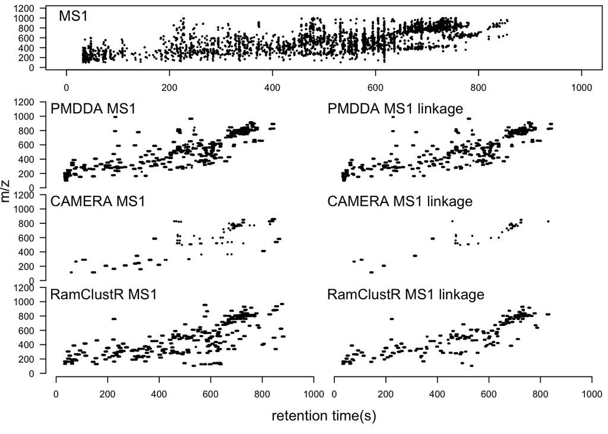

```r
pos <- enviGCMS::getmzrtcsv('rppmzrt.csv')
neg <- enviGCMS::getmzrtcsv('rpnmzrt.csv')

rppms1 <- read.csv('rppms1.csv')
pmddams1 <- rppms1[grepl('pmd',rppms1$file),]
idx <- enviGCMS::getalign(pmddams1$mz,pos$mz,pmddams1$rt,pos$rt,ppm = 5,deltart = 5)
pmddams1link <- pmddams1[unique(idx$xid),]
camerams1 <- rppms1[grepl('camera',rppms1$file),]
idx <- enviGCMS::getalign(camerams1$mz,pos$mz,camerams1$rt,pos$rt,ppm = 5,deltart = 5)
camerams1link <- camerams1[unique(idx$xid),]
ramms1 <- rppms1[grepl('ram',rppms1$file),]
idx <- enviGCMS::getalign(ramms1$mz,pos$mz,ramms1$rt,pos$rt,ppm = 5,deltart = 5)
ramms1link <- ramms1[unique(idx$xid),]

#png('ms1link.png',width = 1500,height = 1500,res=300)
layout(matrix(c(1,2,4,6,1,3,5,7),nrow = 4,ncol = 2))
par(mar = c(2.5,0,0,0), oma = c(5,4,0.5,0.5), las =1)
plot(pos$mz~pos$rt,pch=19,xlab = 'retention time(s)',ylab = 'm/z',main='',xlim = c(0,1000),ylim = c(0,1200),cex=0.3)
mtext('MS1', side = 3, line = -1.5, adj = 0.025)
par(mar=c(0,0,0,0))
plot(pmddams1$mz~pmddams1$rt,pch=19,xlab = '',ylab = 'm/z',main='',xlim = c(0,1000),ylim = c(0,1200),cex=0.3,axes=F)
axis(side = 2)
mtext('PMDDA MS1', side = 3, line = -1.5, adj = 0.025)
plot(pmddams1link$mz~pmddams1link$rt,pch=19,xlab = '',ylab = 'm/z',main='',xlim = c(0,1000),ylim = c(0,1200),cex=0.3,axes=F)
mtext('PMDDA MS1 linkage', side = 3, line = -1.5, adj = 0.025)
plot(camerams1$mz~camerams1$rt,pch=19,xlab = '',ylab = 'm/z',main='',xlim = c(0,1000),ylim = c(0,1200),cex=0.3,axes=F)
axis(side = 2)
mtext('CAMERA MS1', side = 3, line = -1.5, adj = 0.025)
plot(camerams1link$mz~camerams1link$rt,pch=19,xlab = '',ylab = 'm/z',main='',xlim = c(0,1000),ylim = c(0,1200),cex=0.3,axes=F)
mtext('CAMERA MS1 linkage', side = 3, line = -1.5, adj = 0.025)
plot(ramms1$mz~ramms1$rt,pch=19,xlab = 'retention time(s)',ylab = 'm/z',main='',xlim = c(0,1000),ylim = c(0,1200),cex=0.3,axes=F)
mtext('RamClustR MS1', side = 3, line = -1.5, adj = 0.025)
axis(side = 2)
axis(side = 1)
plot(ramms1link$mz~ramms1link$rt,pch=19,xlab = 'retention time(s)',ylab = 'm/z',main='',xlim = c(0,1000),ylim = c(0,1200),cex=0.3,axes=F)
mtext('RamClustR MS1 linkage', side = 3, line = -1.5, adj = 0.025)
axis(side = 1)
mtext("retention time(s)", side = 1, outer = TRUE, line = 3)
mtext("m/z", side = 2, outer = TRUE, line = 3, las = 3)
```

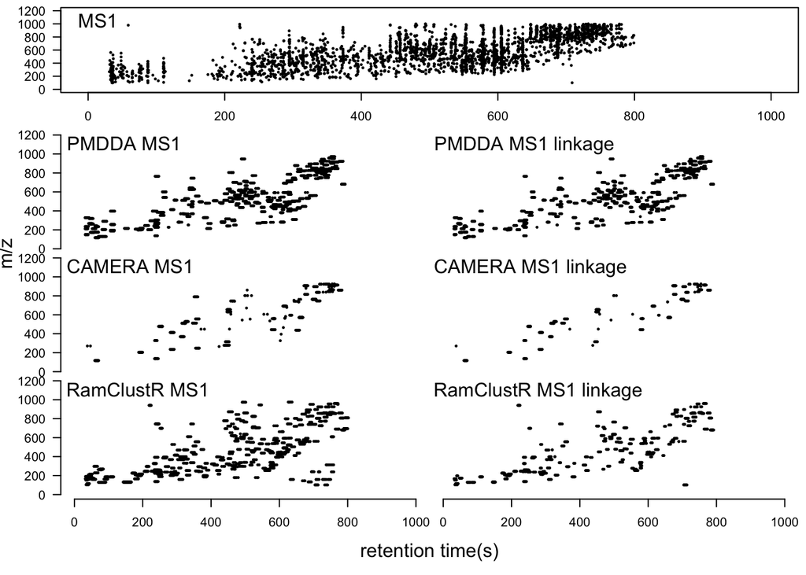

```r
#dev.off()

rpnms1 <- read.csv('rpnms1.csv')
pmddams1 <- rpnms1[grepl('pmd',rpnms1$file),]
idx <- enviGCMS::getalign(pmddams1$mz,neg$mz,pmddams1$rt,neg$rt,ppm = 5,deltart = 5)
pmddams1link <- pmddams1[unique(idx$xid),]
camerams1 <- rpnms1[grepl('camera',rpnms1$file),]
idx <- enviGCMS::getalign(camerams1$mz,neg$mz,camerams1$rt,neg$rt,ppm = 5,deltart = 5)
camerams1link <- camerams1[unique(idx$xid),]
ramms1 <- rpnms1[grepl('ram',rpnms1$file),]
idx <- enviGCMS::getalign(ramms1$mz,neg$mz,ramms1$rt,neg$rt,ppm = 5,deltart = 5)
ramms1link <- ramms1[unique(idx$xid),]

#png('ms1linkn.png',width = 1500,height = 1500,res=300)
layout(matrix(c(1,2,4,6,1,3,5,7),nrow = 4,ncol = 2))
par(mar = c(2.5,0,0,0), oma = c(5,4,0.5,0.5), las =1)
plot(neg$mz~neg$rt,pch=19,xlab = 'retention time(s)',ylab = 'm/z',main='',xlim = c(0,1000),ylim = c(0,1200),cex=0.3)
mtext('MS1', side = 3, line = -1.5, adj = 0.025)
par(mar=c(0,0,0,0))
plot(pmddams1$mz~pmddams1$rt,pch=19,xlab = '',ylab = 'm/z',main='',xlim = c(0,1000),ylim = c(0,1200),cex=0.3,axes=F)
axis(side = 2)
mtext('PMDDA MS1', side = 3, line = -1.5, adj = 0.025)
plot(pmddams1link$mz~pmddams1link$rt,pch=19,xlab = '',ylab = 'm/z',main='',xlim = c(0,1000),ylim = c(0,1200),cex=0.3,axes=F)
mtext('PMDDA MS1 linkage', side = 3, line = -1.5, adj = 0.025)
plot(camerams1$mz~camerams1$rt,pch=19,xlab = '',ylab = 'm/z',main='',xlim = c(0,1000),ylim = c(0,1200),cex=0.3,axes=F)
axis(side = 2)
mtext('CAMERA MS1', side = 3, line = -1.5, adj = 0.025)
plot(camerams1link$mz~camerams1link$rt,pch=19,xlab = '',ylab = 'm/z',main='',xlim = c(0,1000),ylim = c(0,1200),cex=0.3,axes=F)
mtext('CAMERA MS1 linkage', side = 3, line = -1.5, adj = 0.025)
plot(ramms1$mz~ramms1$rt,pch=19,xlab = 'retention time(s)',ylab = 'm/z',main='',xlim = c(0,1000),ylim = c(0,1200),cex=0.3,axes=F)
mtext('RamClustR MS1', side = 3, line = -1.5, adj = 0.025)
axis(side = 2)
axis(side = 1)
plot(ramms1link$mz~ramms1link$rt,pch=19,xlab = 'retention time(s)',ylab = 'm/z',main='',xlim = c(0,1000),ylim = c(0,1200),cex=0.3,axes=F)
mtext('RamClustR MS1 linkage', side = 3, line = -1.5, adj = 0.025)
axis(side = 1)
mtext("retention time(s)", side = 1, outer = TRUE, line = 3)
mtext("m/z", side = 2, outer = TRUE, line = 3, las = 3)
```

```r
#dev.off()
```

### GNPS molecular networking comparison

This section will compare the annotation results based on GNPS molecular networking and generate figure 2 in the manuscript.

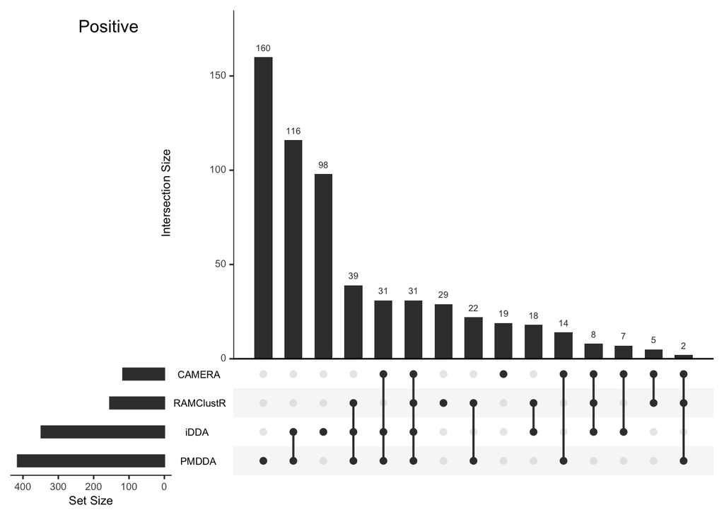

```r
# import the MS1 full scan peak list
rpp <- enviGCMS::getmzrtcsv('rppmzrt.csv')
rpn <- enviGCMS::getmzrtcsv('rpnmzrt.csv')
# import GNPS molecular network results for positive mode
posanno <- read.csv('rppanno.csv')
RPP1 <- posanno[,c(9:12)]
# positive data and align them to MS1 full scan
posalign <- enviGCMS::getalign(posanno$precursor.mass,rpp$mz,posanno$RTMean,rpp$rt)
posgnps <- RPP1[unique(posalign$xid),]
# 599
posgnps[posgnps>0] <- 1
colnames(posgnps) <- c('iDDA','PMDDA','RAMClustR','CAMERA')
# generate UpSet plot as figure 1
library('UpSetR')
#png('comparepclust.png',res=300,width = 1500,height = 1500)
listinput <- list(PMDDA=which(posgnps$PMDDA!=0),CAMERA=which(posgnps$CAMERA!=0),RAMClustR=which(posgnps$RAMClustR!=0),iDDA=which(posgnps$iDDA!=0))
upset(fromList(listinput), order.by = "freq",nsets = 4)
grid::grid.text("Positive",x = 0.15, y=0.95, gp=grid::gpar(fontsize=12))
```

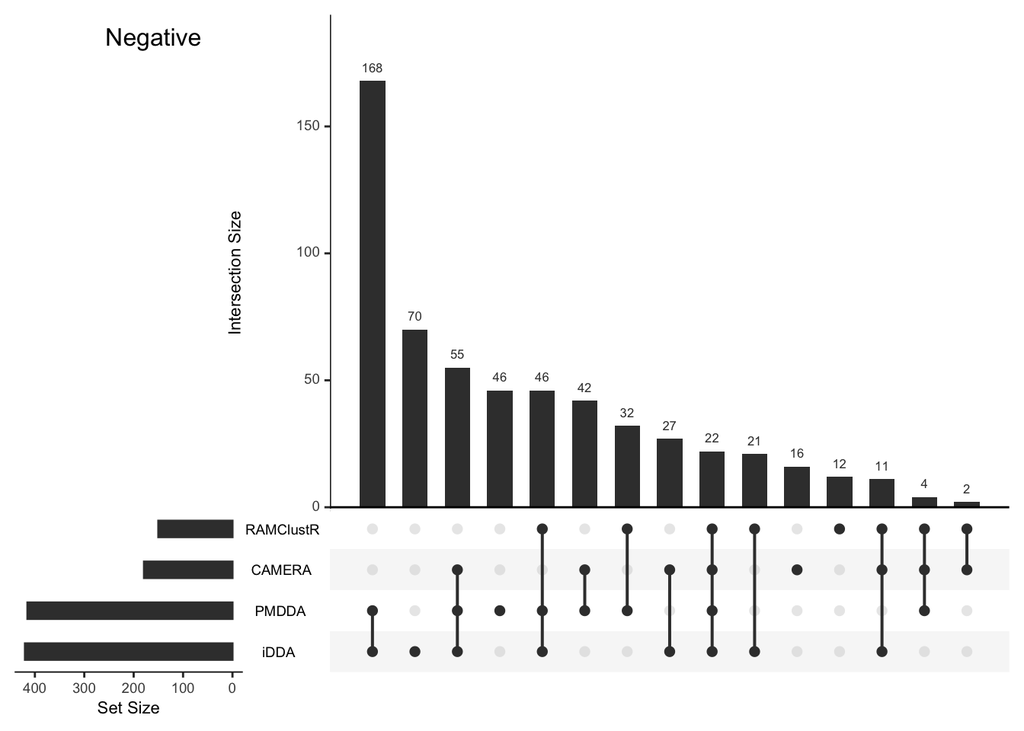

```r
#dev.off()
# import GNPS molecular network results for negative mode
neganno <- read.csv('rpnanno.csv')
RPN1 <- neganno[,c(9:12)]
# negative data and align them to MS1 full scan
negalign <- enviGCMS::getalign(neganno$precursor.mass,rpn$mz,neganno$RTMean,rpn$rt)
neggnps <- RPN1[unique(negalign$xid),]
# 590
neggnps[neggnps>0] <- 1
colnames(neggnps) <- c('iDDA','PMDDA','CAMERA','RAMClustR')
# generate UpSet plot as figure 2
library('UpSetR')
#png('comparenclust.png',res=300,width = 1500,height = 1500)
listinput <- list(PMDDA=which(posgnps$PMDDA!=0),CAMERA=which(neggnps$CAMERA!=0),RAMClustR=which(neggnps$RAMClustR!=0),iDDA=which(neggnps$iDDA!=0))
upset(fromList(listinput), order.by = "freq",nsets = 4)
grid::grid.text("Negative",x = 0.15, y=0.95, gp=grid::gpar(fontsize=12))
```

```r
#dev.off()
```

### GNPS compounds annotation comparison

This chunk will generate figure S3 to compare the compounds annotation results.

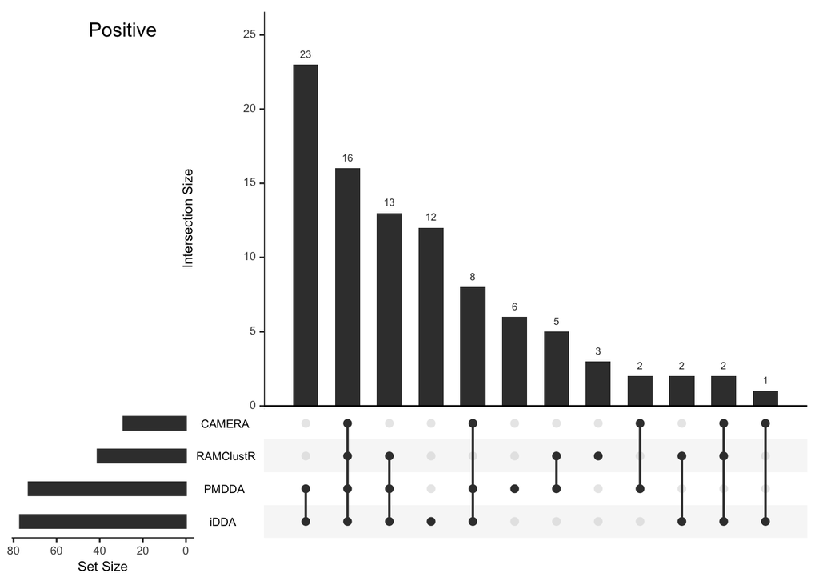

```r
# import the MS1 full scan peak list
rpp <- enviGCMS::getmzrtcsv('rppmzrt.csv')
rpn <- enviGCMS::getmzrtcsv('rpnmzrt.csv')
# import GNPS annotation results with compounds name and remove the duplicates for positive mode
posanno <- read.csv('rppanno.csv')
posanno2 <- posanno[!duplicated(posanno$Compound_Name)&(posanno$IonMode == 'positive'|posanno$IonMode == 'Positive'),]
# positive data and align them to MS1 full scan
RPP1 <- posanno2[,c(9:12)]
posalign <- enviGCMS::getalign(posanno2$precursor.mass,rpp$mz,posanno2$RTMean,rpp$rt)
# remove the annotation without MS1 linkage
posgnps <- RPP1[unique(posalign$xid),]
# 93
posgnps[posgnps>0] <- 1
colnames(posgnps) <- c('iDDA','PMDDA','RAMClustR','CAMERA')
# compare the results across different workflow
# generate UpSet plot as figure S3
library('UpSetR')
#png('comparep.png',res=300,width = 1500,height = 1500)
listinput <- list(Matrix=which(posgnps$DDAMatrix!=0),DDA=which(posgnps$DDA!=0),PMDDA=which(posgnps$PMDDA!=0),CAMERA=which(posgnps$CAMERA!=0),RAMClustR=which(posgnps$RAMClustR!=0),iDDA=which(posgnps$iDDA!=0))
upset(fromList(listinput), order.by = "freq",nsets = 6)
grid::grid.text("Positive",x = 0.15, y=0.95, gp=grid::gpar(fontsize=12))
```

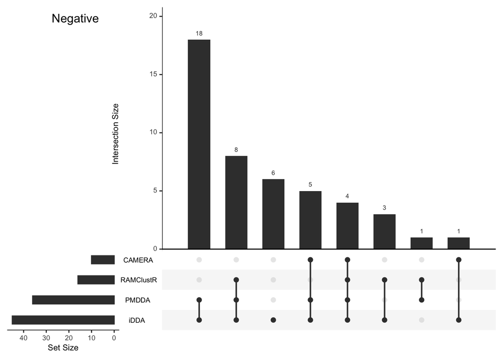

```r
#dev.off()
# import GNPS annotation results with compounds name and remove the duplicates for negative mode
neganno <- read.csv('rpnanno.csv')
neganno2 <- neganno[!duplicated(neganno$Compound_Name)&(neganno$IonMode == 'negative'|neganno$IonMode == 'Negative'),]
# negative data and align them to MS1 full scan
RPN1 <- neganno2[,c(9:12)]
negalign <- enviGCMS::getalign(neganno2$precursor.mass,rpn$mz,neganno2$RTMean,rpn$rt)
neggnps <- RPN1[unique(negalign$xid),]
# 46
neggnps[neggnps>0] <- 1
colnames(neggnps) <- c('iDDA','PMDDA','RAMClustR','CAMERA')
# generate UpSet plot as figure S3
library('UpSetR')
#png('comparen.png',res=300,width = 1500,height = 1500)
listinput <- list(PMDDA=which(neggnps$PMDDA!=0),CAMERA=which(neggnps$CAMERA!=0),RAMClustR=which(neggnps$RAMClustR!=0),iDDA=which(neggnps$iDDA!=0))
upset(fromList(listinput), order.by = "freq",nsets = 4)
grid::grid.text("Negative",x = 0.15, y=0.95, gp=grid::gpar(fontsize=12))
```

```r
#dev.off()
```

### xcms extracted spectra comparison

This section use xcms package to extract MS2 spectra as mgf files and compared different workflow (PMDDA, CAMERA, RAMClustR). Those mgf files can be saved for further annotation. This chunk will also save the linked MS1 full scan data to check the coverage of different workflow. Those linked csv files name have a pattern with their workflow name plus `mzrt.csv`.

```r
# this is the function to compare the linked MS1 and MS2 data among different workflow and save them as mgf files
ms1linkms2 <- function(filems1,filems2,name){
  dda_data <- MSnbase::readMSData(filems2, mode = "onDisk")
  cwp <- xcms::CentWaveParam(noise = 0, ppm = 10,
                     peakwidth = c(9.1, 90.5),mzdiff = -0.0197)
  dda_data <- xcms::findChromPeaks(dda_data, param = cwp)
  dda_spectra <- xcms::chromPeakSpectra(dda_data)

  mz <- precursorMz(dda_spectra)
  rt <- rtime(dda_spectra)

  neg <- enviGCMS::getmzrtcsv(filems1)
  idx <- enviGCMS::getalign(mz,neg$mz,rt,neg$rt,ppm = 5,deltart = 5)
  idx$grp <- paste0('M',round(idx$mz2,4),'T',round(idx$rt2,1))
  x <- dda_spectra[idx$xid]
  message(paste(length(unique(idx$grp)),'spectra could be found'))
  idx2 <- enviGCMS::getalign(neg$mz,mz,neg$rt,rt,ppm = 5,deltart = 5)
  dda <- enviGCMS::getfilter(neg,rowindex = unique(idx2$xid))
  x@elementMetadata$peak_id <- idx$grp
  spec <- combineSpectra(x, fcol="peak_id", method = consensusSpectrum, mzd = 0.02,ppm = 5, minProp = 0.6, weighted = FALSE,intensityFun = sum, mzFun = median,timeDomain=TRUE)
  scan <- sapply(spec,function(x) x@acquisitionNum)
  spec@elementMetadata$peak_id <- paste0('FT',scan)
  writeMgfData(spec,paste0(name,'.mgf'))
  # Row.names <- paste0('FT',scan)[match(rownames(dda$data),unique(idx$grp))]
  # mzmed <- dda$mz
  # rtmed <- dda$rt
  # df <- cbind(Row.names,mzmed,rtmed,dda$data)
  # write.table(df,paste0(name,'.txt'),sep = '\t',row.names = F)
  enviGCMS::getcsv(dda,name)
}
# extract positive MS2 data
library(xcms)
mzdatapath <- 'MS2'
file <- list.files(mzdatapath,
                          recursive = TRUE, full.names = TRUE)
file <- file[grepl('RPP',file)]

camera <- file[grepl('CAMERA',file)]
pmdda <- file[grepl('pmd',file)]
ramclustr <- file[grepl('RAMClustR',file)]
idda <- file[grepl('iDDA',file)]
posneg <- file[grepl('posneg',file)]

ms1linkms2('rppmzrt.csv',posneg,'posneg')
# 33
ms1linkms2('rppmzrt.csv',ramclustr,'ramclustr')
# 163
ms1linkms2('rppmzrt.csv',camera,'camera')
# 34
ms1linkms2('rppmzrt.csv',pmdda,'pmdda')
# 293
# extract negative MS2 data
file <- list.files(mzdatapath,
                          recursive = TRUE, full.names = TRUE)
file <- file[grepl('RPN',file)]
camera <- file[grepl('CAMERA',file)]
pmdda <- file[grepl('pmd',file)]
ramclustr <- file[grepl('RAMClustR',file)]
posneg <- file[grepl('posneg',file)]

ms1linkms2('rpnmzrt.csv',posneg,'posnegn')
# 33
ms1linkms2('rpnmzrt.csv',ramclustr,'ramclustrn')
# 150
ms1linkms2('rpnmzrt.csv',camera,'cameran')
# 46
ms1linkms2('rpnmzrt.csv',pmdda,'pmddan')
# 254
```

### low intensity issue

This chunk is used to check the coverage of low intensity MS1 precursor of different workflows and compare with iterative DDA workflow (figure S6).

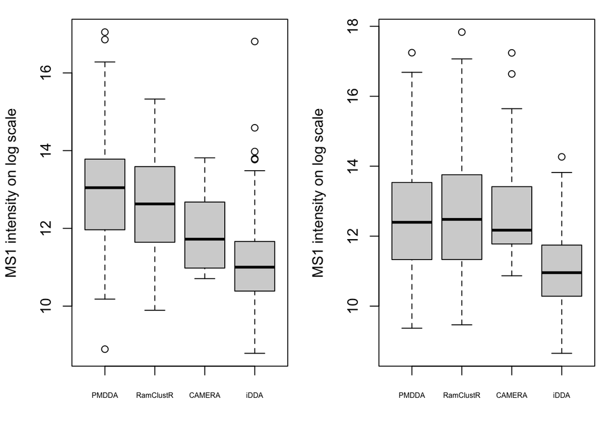

```r
pmdda <- enviGCMS::getmzrtcsv('pmddanmzrt.csv')
dfp <- paste0(round(pmdda$mz,4),'@',round(pmdda$rt,1))
# 126
camera <- enviGCMS::getmzrtcsv('cameranmzrt.csv')
dfc <- paste0(round(camera$mz,4),'@',round(camera$rt,1))
# 33
ramclustr <- enviGCMS::getmzrtcsv('ramclustrnmzrt.csv')
dfr <- paste0(round(ramclustr$mz,4),'@',round(ramclustr$rt,1))
# 66
idda <- enviGCMS::getmzrtcsv('iddanmzrt.csv')
dfi <-paste0(round(idda$mz,4),'@',round(idda$rt,1))

mpmdda <- apply(pmdda$data,1,mean)
mcamera <- apply(camera$data,1,mean)
mramclustr <- apply(ramclustr$data,1,mean)
midda <- apply(idda$data,1,mean)

i <- setdiff(dfi,unique(c(dfc,dfp,dfr)))
p <- setdiff(dfp,unique(c(dfc,dfi,dfr)))
r <- setdiff(dfr,unique(c(dfc,dfi,dfp)))
c <- setdiff(dfc,unique(c(dfi,dfp,dfr)))
mpmdda <- apply(pmdda$data[dfp%in%p,],1,mean)
midda <- apply(idda$data[dfi%in%i,],1,mean)
mcamera <- apply(camera$data[dfc%in%c,],1,mean)
mramclustr <- apply(ramclustr$data[dfr%in%r,],1,mean)

#png('MS1intensity.png',width=2500,height=1000,res=300)
par(mfrow=c(1,2),mar=c(4,4,1,1)+0.1)
boxplot(log(mpmdda),log(mramclustr),log(mcamera),log(midda),xaxt='n',ylab='MS1 intensity on log scale')
axis(1,at=c(1:4),labels = c('PMDDA','RamClustR','CAMERA','iDDA'),cex.axis=0.5)

pmdda <- enviGCMS::getmzrtcsv('pmddamzrt.csv')
dfp <- paste0(round(pmdda$mz,4),'@',round(pmdda$rt,1))
# 126
camera <- enviGCMS::getmzrtcsv('cameramzrt.csv')
dfc <- paste0(round(camera$mz,4),'@',round(camera$rt,1))
# 33
ramclustr <- enviGCMS::getmzrtcsv('ramclustrmzrt.csv')
dfr <- paste0(round(ramclustr$mz,4),'@',round(ramclustr$rt,1))
# 66
idda <- enviGCMS::getmzrtcsv('iddamzrt.csv')
dfi <-paste0(round(idda$mz,4),'@',round(idda$rt,1))

mpmdda <- apply(pmdda$data,1,mean)
mcamera <- apply(camera$data,1,mean)
mramclustr <- apply(ramclustr$data,1,mean)
midda <- apply(idda$data,1,mean)

i <- setdiff(dfi,unique(c(dfc,dfp,dfr)))
p <- setdiff(dfp,unique(c(dfc,dfi,dfr)))
r <- setdiff(dfr,unique(c(dfc,dfi,dfp)))
c <- setdiff(dfc,unique(c(dfi,dfp,dfr)))
mpmdda <- apply(pmdda$data[dfp%in%p,],1,mean)
midda <- apply(idda$data[dfi%in%i,],1,mean)
mcamera <- apply(camera$data[dfc%in%c,],1,mean)
mramclustr <- apply(ramclustr$data[dfr%in%r,],1,mean)

boxplot(log(mpmdda),log(mramclustr),log(mcamera),log(midda),xaxt='n',ylab='MS1 intensity on log scale')
axis(1,at=c(1:4),labels = c('PMDDA','RamClustR','CAMERA','iDDA'),cex.axis=0.5)
```

```r
#dev.off()
```

### Positive Negative connection

This section can be used to build the connection between positive and negative mode and generate figure 3 in the manuscript.

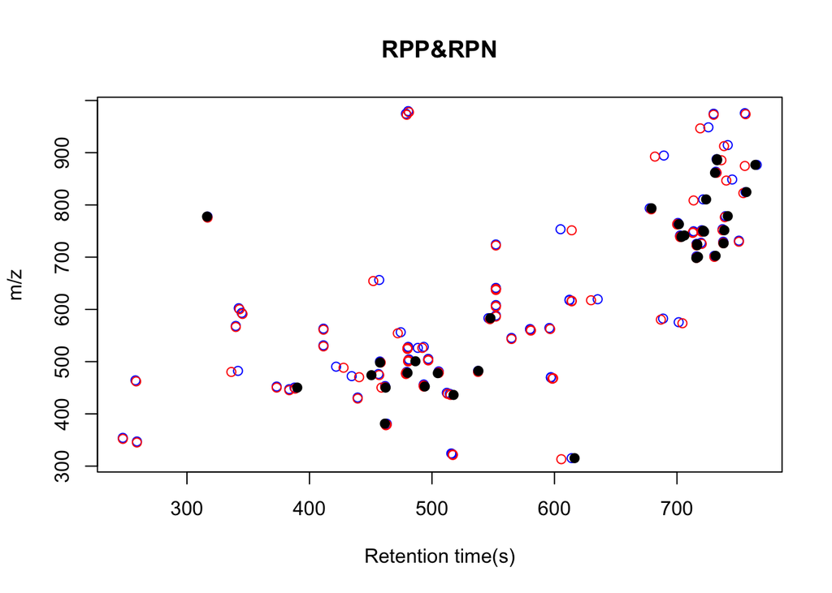

```r
# import the MS1 data from both modes
pos <- enviGCMS::getmzrtcsv('rppmzrt.csv')
neg <- enviGCMS::getmzrtcsv('rpnmzrt.csv')
# build the connection
con <- pmd::getposneg(pos,neg)
# filter the connection based on correlation and retention time
concor <- con[abs(con$diffrt)<10&abs(con$cor)>0.6,]
write.csv(concor,'posneg.csv')
concor <- read.csv('posneg.csv')
# 100
# generate precursor ions list
# ppn <- gettarget(concor$pos,concor$rt,n=6,Drt = 0.2,ce=20,name = 'posnegp')
# npn <- gettarget(concor$neg,concor$rt,n=6,Drt = 0.2,ce=20,name = 'posnegn')
# annotation by PMDDA & GNPS
anno <- read.csv('posneganno.csv')
anno2 <- anno[(anno$IonMode == 'Positive'|anno$IonMode == 'Negative')&grepl('M\\+H|M\\-H',anno$Adduct)&!duplicated(anno$Compound_Name),]
# 35
# PE(P-16:0/20:4) and PE(P-16:0/18:2)
# png('posneg.png',width = 2000,height = 1500,res = 300)
plot(concor$pos~concor[,3], main = 'RPP&RPN',xlab='Retention time(s)',ylab = 'm/z',col='blue')
points(concor$neg~concor[,5],col='red')
points(anno2$parent.mass~anno2$RTMean,pch=19)
```

```r
# dev.off()
```